# Independent Project Markdown MESSY VERSION NOT CLEAN

MAGGIE CLEAN THE CODE IN A DOCUMENT COPY

Maggie and Kendal

2026-07-20

# Project Overview:

The goal of this project is to address possible sampling gaps within the methods of the TEMPEST IV sampling campaign.

In order to sample canopy data, branches need to be removed from the tree, re-cut in a bucket of saltwater, and brought to the IRGAs in the lab. There is an unavoidable time delay between when the sample is removed, when the sample has access to water, and when the sample begins measurement. We want to know whether any of these actions impacts the ability of the leaves on the sample branch to photosynthesize so that we can better understand the veg campaign data.

Additionally, it is difficult to know (and therefore sample) exactly when the trees in the saltwater plot are actively uptaking saltwater, and what the direct effects of this uptake would be. However, by snipping a sample in a bucket of saltwater, we may be able to mimic this uptake.

This project investigates whether 1. the **action of snipping** a branch off the main stem 2. the **time delay** for that branch accessing water, and 3. the **type of water** the branch is in (i.e. freshwater versus saltwater) impact the photosynthesis of the three focal TEMPEST species (tulip poplar, red maple, and beech).

Data collection is divided into two cycles:

| **Cycle A** | **Cycle B** |
| --- | --- |
| Control *(attached to tree)* | Control *(attached to tree)* |
| Bucket *(snipped in a bucket of freshwater, no time delay)* | Fresh *(snipped in a bucket of freshwater, ~1 min delay)* |
| Detached *(snipped without providing any water source)* | Salt *(snipped in a bucket of saltwater, ~1 min delay)* |

Each cycle runs for 75 minutes, logging data every 120 seconds. Cycles where a treatment is applied log one reading before the treatment.

# Code Output:

```r
#could i make this a function?? does r do functions???
#I MADE IT A FUNCTION!!! (it works!!) YAY!!
cleanData <- function(dataSheet, cycleNumber, cycleType, spp, obsStart, obsEnd) {
  #dataSheet = data, cylceNumber = String, cycleType = String, spp = String, obsStart = int, obsEnd = int
  dataSheet %>% #grabs from correct data sheet
    filter(between(obs, obsStart, obsEnd)) %>% #filters to correct log numbers
    mutate(logNum = obs - (obsStart- 1)) %>% #makes it so logNum always starts on 1
    mutate(name = cycleNumber) %>% #(like LITU_A1 = tulip cycle a rep 1), to ID cycle #
    mutate(cycle = cycleType) %>% #adds cycle type
    mutate(species = spp) %>% #adds species
    select(logNum, A, gsw, date, Ci, cycle, species) #get data!
}

#LITU
LITU_A1_control <- cleanData(PNNLDay1, "LITU_A1", "controlA", "LITU", 2, 39)
LITU_A1_detached <- cleanData(UTDay1, "LITU_A1", "detached", "LITU", 1, 38)
LITU_A1_bucket <- cleanData(NoNameDay1, "LITU_A1", "bucket", "LITU", 1, 38)

LITU_B1_control <- cleanData(PNNLDay1, "LITU_B1", "controlB", "LITU", 41, 77)
LITU_B1_fresh <- cleanData(NoNameDay1, "LITU_B1", "fresh", "LITU", 40, 77)
LITU_B1_salt <- cleanData(UTDay1, "LITU_B1", "salt", "LITU", 40, 77)

LITU_A2_control <- cleanData(PNNLDay2, "LITU_A2", "controlA", "LITU", 1, 38)
LITU_A2_detached <- cleanData(UTDay2, "LITU_A2", "detached", "LITU", 1, 38)
LITU_A2_bucket <- cleanData(NoNameDay2, "LITU_A2", "bucket", "LITU", 1, 38)

LITU_B2_control <- cleanData(PNNLDay2, "LITU_B2", "controlB", "LITU", 39, 75)
LITU_B2_fresh <- cleanData(NoNameDay2, "LITU_B2", "fresh", "LITU", 39, 76)
LITU_B2_salt <- cleanData(UTDay2, "LITU_B2", "salt", "LITU", 39, 76)


#FAGR
FAGR_A1_control <- cleanData(PNNLDay1, "FAGR_A1", "controlA", "FAGR", 79, 116)
FAGR_A1_detached <- cleanData(UTDay1, "FAGR_A1", "detached", "FAGR", 79, 116)
FAGR_A1_bucket <- cleanData(NoNameDay1, "FAGR_A1", "bucket", "FAGR", 80, 117)

FAGR_B1_control <- cleanData(PNNLDay2, "FAGR_B1", "controlB", "FAGR", 76, 112)
FAGR_B1_fresh <- cleanData(NoNameDay2, "FAGR_B1", "fresh", "FAGR", 77, 114)
FAGR_B1_salt <- cleanData(UTDay2, "FAGR_B1", "salt", "FAGR", 77, 114)



#this was me doing it manually before :) ----
control1 <- PNNLTest %>% #control cycle 1, found in PNNL data
  filter(obs <= 37) %>% #includes logs 0-37. real log should also include 38!!
  mutate(logNum = obs) %>% #adds logNum, though here it's the same as obs (I want consistent names)
  mutate(cycle = "control1") %>% #adds "cycle" identifier, for color/sorting later
  mutate(species = "beech") %>%  #adds "species" identifier, might be helpful later?
  select(logNum, A, gsw, date, Ci, cycle, species) #data that we might care about

control2 <- PNNLTest %>%
  filter(obs >= 38) %>% #this should be 39 for the real thing!!
  mutate(logNum = obs-37) %>% #the logNum now starts at 1 again, though this should be 38 for the real thing!
  mutate(cycle = "control2") %>%
  mutate(species = "beech") %>%
  select(logNum, A, gsw, date, Ci, cycle, species)

bucket <- UTTest %>%
  filter(obs <= 37) %>%
  mutate(logNum = obs) %>%
  mutate(cycle = "bucket") %>%
  mutate(species = "beech") %>%
  select(logNum, A, gsw, date, Ci, cycle, species)

fresh <- UTTest%>%
  filter(obs >= 38) %>%
  mutate(logNum = obs - 37) %>%
  mutate(cycle = "fresh") %>%
  mutate(species = "beech") %>%
  select(logNum, A, gsw, date, Ci, cycle, species)

detached <- NoNameTest %>%
  filter(obs <= 37) %>%
  mutate(logNum = obs) %>%
  mutate(cycle = "detached") %>%
  mutate(species = "beech") %>%
  select(logNum, A, gsw, date, Ci, cycle, species)

salt <- NoNameTest %>%
  filter(obs >= 38) %>%
  mutate(logNum = obs - 37) %>%
  mutate(cycle = "salt") %>%
  mutate(species = "beech") %>%
  select(logNum, A, gsw, date, Ci, cycle, species)
```

# Graphs

ideas: can i have it so this page shows a dropdown menu OR a “enter what you want to see” ?

## one leaf:

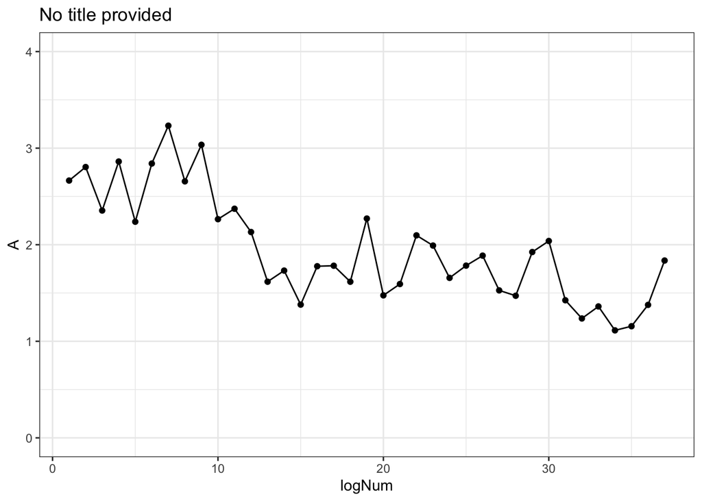

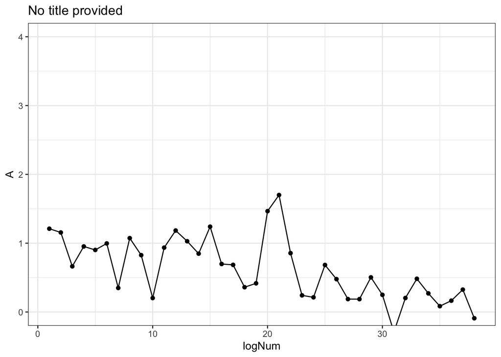

## one cycle:

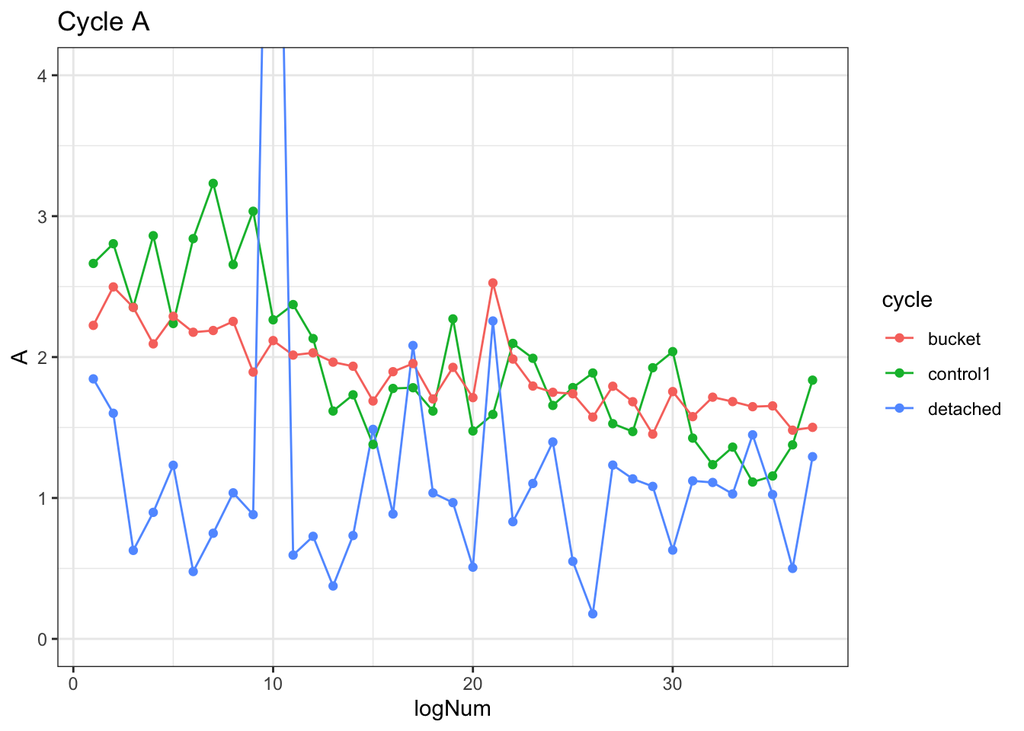

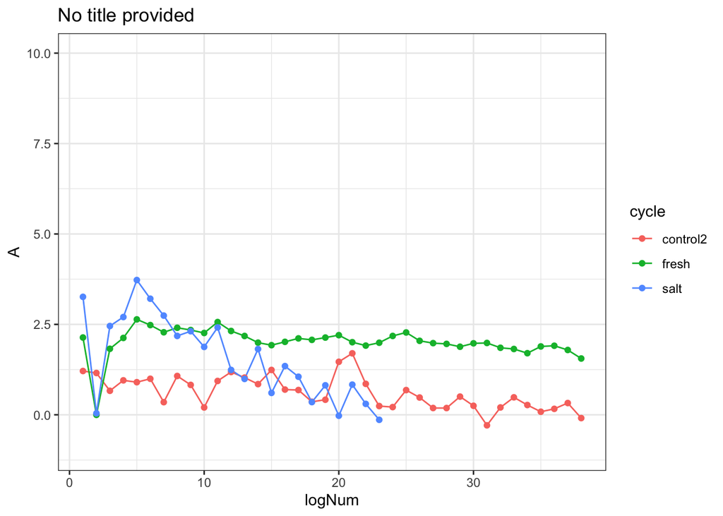

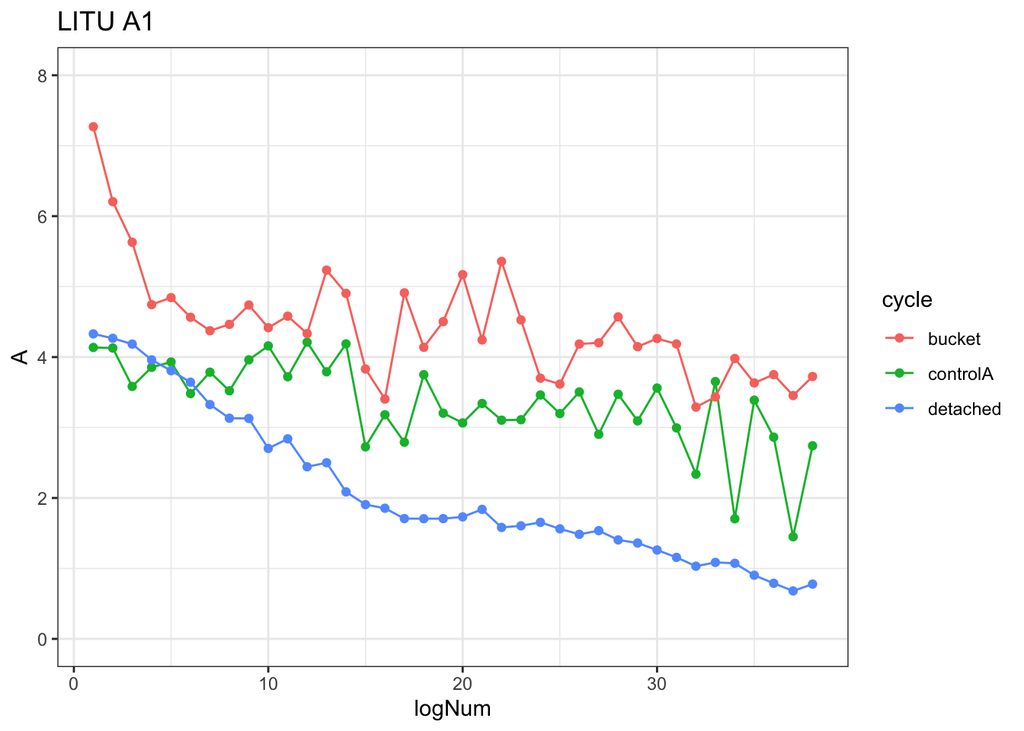

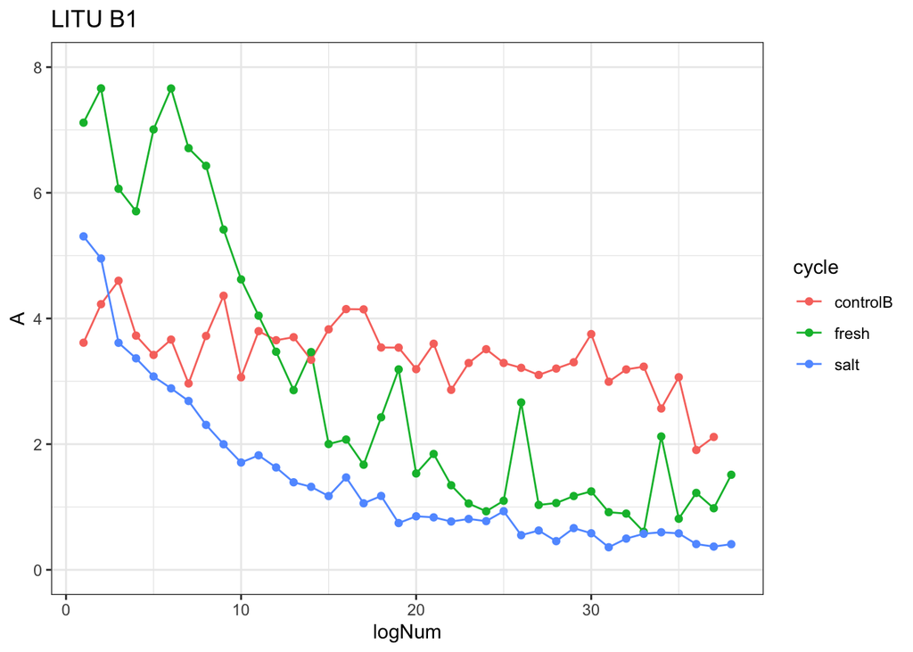

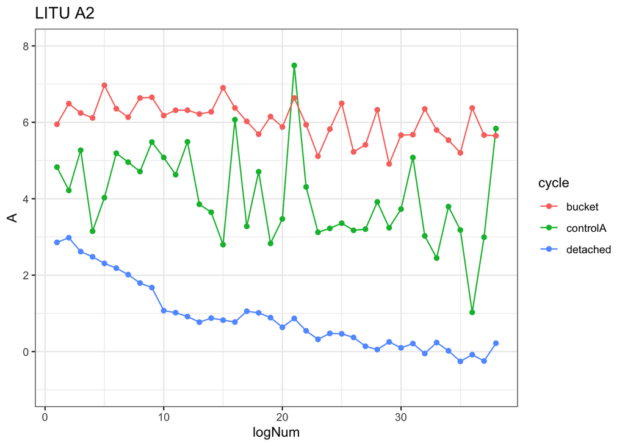

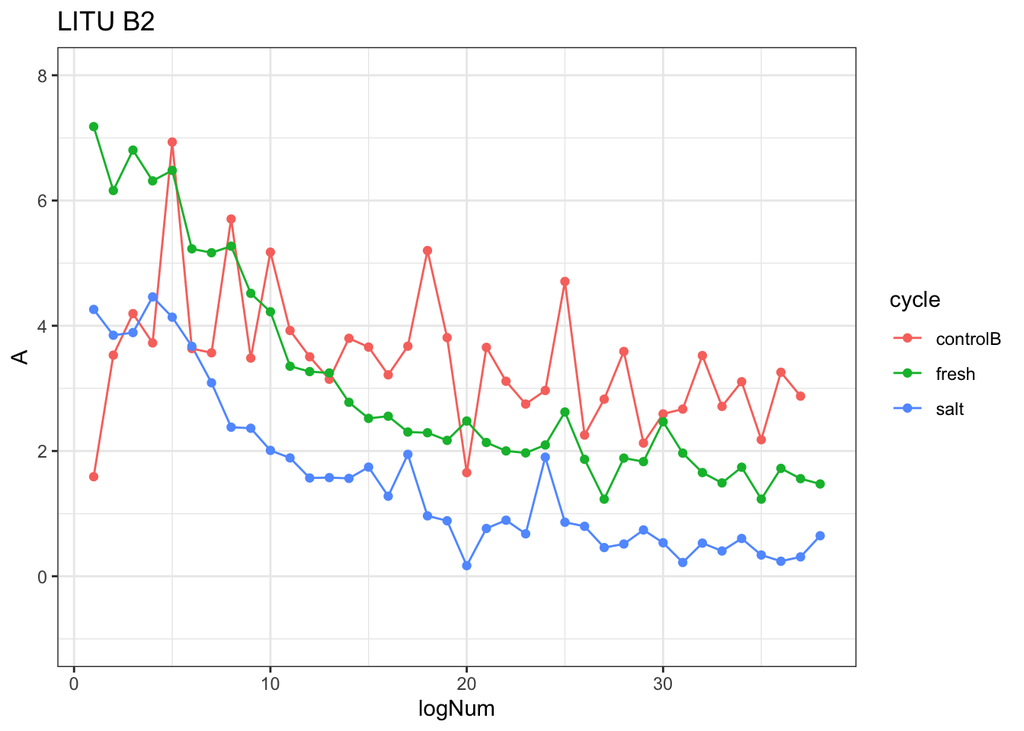

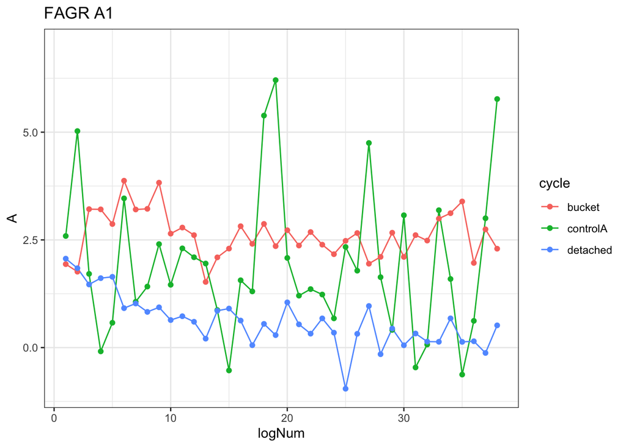

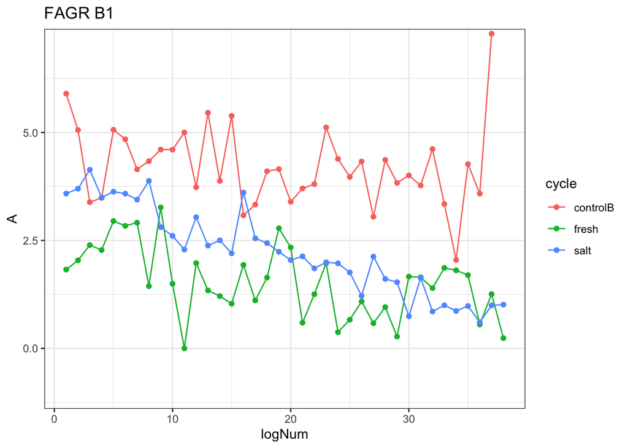